# Clustering and classification

#### In relation to variable distribution and how they might be related we could ask whether the crime rate in Boston is anyhow linked to the value of homes, i.e, whether the old Hollywood adage of crime-ridden areas of Boston & its dingy houses v/s affluent suburbs with lower crime rates hold true or not

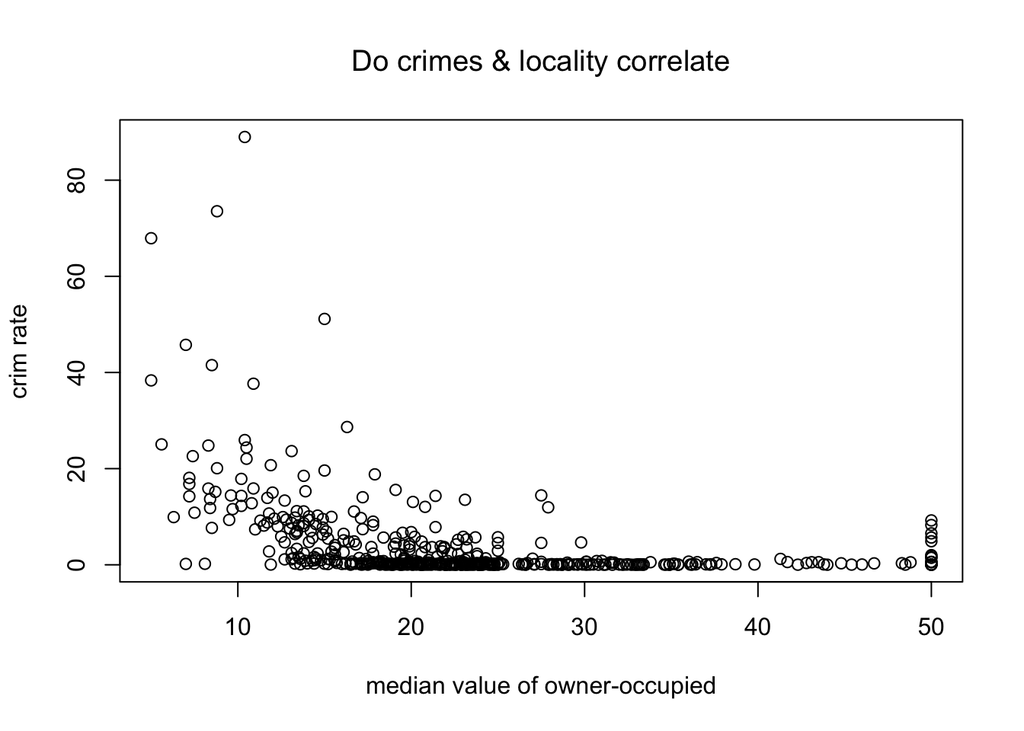

```r
# Do crimes & locality correlate in Boston?
plot(crim ~ medv, data=Boston, main = "Do crimes & locality correlate", xlab = "median value of owner-occupied", ylab = "crim rate")
```

#### We see a rather interesting pattern here in relation to crime rate and housing prices. The crime rates for affluent neighbourhoods seem quite low in relation to lower/cheaper houses.

#### In this same manner we can explore more such variables against crime rates and investigate their distributions

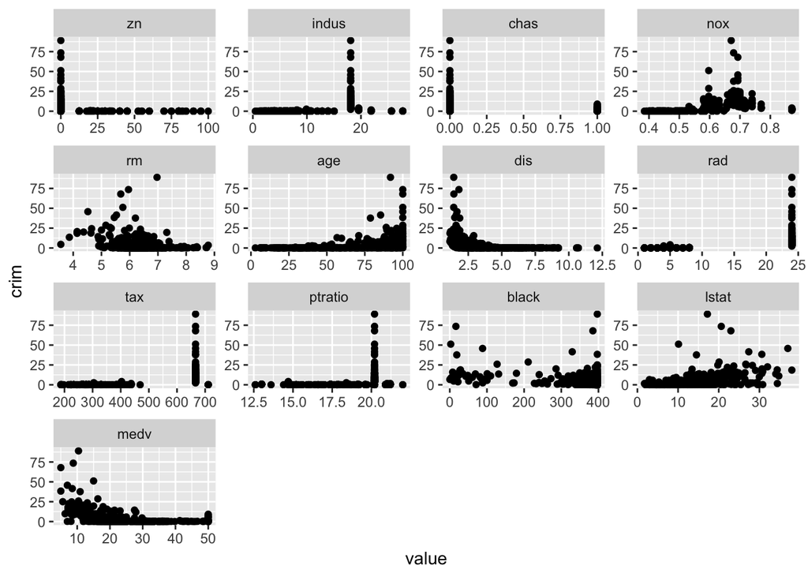

```r
# How do other variables stack up against crime rates? Do we see patterns?
molten <- melt(Boston, id = "crim")
ggplot(molten, aes(x = value, y = crim))+
  facet_wrap( ~ variable, scales = "free")+
  geom_point()
```

#### From above figure we do see rather some interesting patterns especially related to crime rates.

## Standardize & observe

```r
# Centering and standardizing variables
boston_scaled <- scale(Boston)

# Summaries of the scaled variables
glimpse(boston_scaled)
```

```
##  num [1:506, 1:14] -0.419 -0.417 -0.417 -0.416 -0.412 ...
##  - attr(*, "dimnames")=List of 2
##   ..$ : chr [1:506] "1" "2" "3" "4" ...
##   ..$ : chr [1:14] "crim" "zn" "indus" "chas" ...
##  - attr(*, "scaled:center")= Named num [1:14] 3.6135 11.3636 11.1368 0.0692 0.5547 ...
##   ..- attr(*, "names")= chr [1:14] "crim" "zn" "indus" "chas" ...
##  - attr(*, "scaled:scale")= Named num [1:14] 8.602 23.322 6.86 0.254 0.116 ...
##   ..- attr(*, "names")= chr [1:14] "crim" "zn" "indus" "chas" ...
```

```r
summary(boston_scaled)
```

```
##       crim                 zn               indus
##  Min.   :-0.419367   Min.   :-0.48724   Min.   :-1.5563
##  1st Qu.:-0.410563   1st Qu.:-0.48724   1st Qu.:-0.8668
##  Median :-0.390280   Median :-0.48724   Median :-0.2109
##  Mean   : 0.000000   Mean   : 0.00000   Mean   : 0.0000
##  3rd Qu.: 0.007389   3rd Qu.: 0.04872   3rd Qu.: 1.0150
##  Max.   : 9.924110   Max.   : 3.80047   Max.   : 2.4202
##       chas              nox                rm               age
##  Min.   :-0.2723   Min.   :-1.4644   Min.   :-3.8764   Min.   :-2.3331
##  1st Qu.:-0.2723   1st Qu.:-0.9121   1st Qu.:-0.5681   1st Qu.:-0.8366
##  Median :-0.2723   Median :-0.1441   Median :-0.1084   Median : 0.3171
##  Mean   : 0.0000   Mean   : 0.0000   Mean   : 0.0000   Mean   : 0.0000
##  3rd Qu.:-0.2723   3rd Qu.: 0.5981   3rd Qu.: 0.4823   3rd Qu.: 0.9059
##  Max.   : 3.6648   Max.   : 2.7296   Max.   : 3.5515   Max.   : 1.1164
##       dis               rad               tax             ptratio
##  Min.   :-1.2658   Min.   :-0.9819   Min.   :-1.3127   Min.   :-2.7047
##  1st Qu.:-0.8049   1st Qu.:-0.6373   1st Qu.:-0.7668   1st Qu.:-0.4876
##  Median :-0.2790   Median :-0.5225   Median :-0.4642   Median : 0.2746
##  Mean   : 0.0000   Mean   : 0.0000   Mean   : 0.0000   Mean   : 0.0000
##  3rd Qu.: 0.6617   3rd Qu.: 1.6596   3rd Qu.: 1.5294   3rd Qu.: 0.8058
##  Max.   : 3.9566   Max.   : 1.6596   Max.   : 1.7964   Max.   : 1.6372
##      black             lstat              medv
##  Min.   :-3.9033   Min.   :-1.5296   Min.   :-1.9063
##  1st Qu.: 0.2049   1st Qu.:-0.7986   1st Qu.:-0.5989
##  Median : 0.3808   Median :-0.1811   Median :-0.1449
##  Mean   : 0.0000   Mean   : 0.0000   Mean   : 0.0000
##  3rd Qu.: 0.4332   3rd Qu.: 0.6024   3rd Qu.: 0.2683
##  Max.   : 0.4406   Max.   : 3.5453   Max.   : 2.9865
```

```r
# Class of boston_scaled object
class(boston_scaled)
```

```
## [1] "matrix"
```

```r
# Converting to data frame
boston_scaled <- as.data.frame(boston_scaled)

# Summary of the scaled crime rate
summary(Boston$crim)
```

```
##     Min.  1st Qu.   Median     Mean  3rd Qu.     Max.
##  0.00632  0.08204  0.25651  3.61352  3.67708 88.97620
```

```r
# Quantile vector of 'crim'
bins <- quantile(boston_scaled$crim)
bins
```

```
##           0%          25%          50%          75%         100%
## -0.419366929 -0.410563278 -0.390280295  0.007389247  9.924109610
```

```r
# Categorical variable 'crime' from 'crim'
crime <- cut(boston_scaled$crim, breaks = bins, include.lowest = TRUE, label = c("low", "med_low", "med_high", "high"))

# Tabulation of the new factor crime
table(crime)
```

```
## crime
##      low  med_low med_high     high
##      127      126      126      127
```

```r
# Removing original 'crim' from the dataset
boston_scaled <- dplyr::select(boston_scaled, -crim)

# Adding the new categorical value to scaled data
boston_scaled <- data.frame(boston_scaled, crime)

# Number of rows in the Boston dataset
n <- nrow(boston_scaled)
n
```

```
## [1] 506
```

```r
# Choosing randomly 80% of the rows
ind <- sample(n,  size = n * 0.8)
ind
```

```
##   [1]  71 341 179 325 253 163 436 466 277  29 439  56 502 320 164 468 447
##  [18]  49 328 412 256 187 372 388 331 503 239 284 121 273 154 166 191 392
##  [35]  27 109 248 437  43 134 326 241 299  14 210 490 327 365 337 219  42
##  [52] 449 211 282  80 236 243 482 396 152 457 338 114  22  55  16 108 409
##  [69] 500 471 385  50 423  88 265 428 378 204 128 291  84 399  13 234 424
##  [86] 313 456  82  30 233 116 158 100 144 147 403  28 231 150 135 422 113
## [103] 419 269 162 462 149 143 452  77 115 329 165 199 124  76 293 155 275
## [120]   2 224 112  15 221 464 501 438 200 117 408 421  57  23 247 332 160
## [137] 451 225  62 344 435 101 272  47 244 360 208 461  78  35 346  96 176
## [154]   7 330 141 381 182 214 433 190 230 413 348 270 232 132  51 168 317
## [171]  24 318 499 497 343 148 316 504  68   1 157 105 308  64 278 473 174
## [188]  86 476 323 393 279 258 377 250 288 481 463 376 145 496 470 129 254
## [205] 434 386 218 167 410 491 151  70 324 229 285 276  92  46 418 195 375
## [222] 130  98  12  94  10 455 289  44 420 363 339 169  18 138 453 222 146
## [239] 430 246 283 373 217  81 206 268 186 442  32 267 354 460 383  31 181
## [256] 259 302 286 107 185 355  54 296  83 311 369 322 183 342 458  26 257
## [273] 238 387 252 295 137 271 223 287 379 319 352 370 274 380 280 478 368
## [290] 126 196  66 260 309 307 184  93 357 479 411  60 333 395 153  40 170
## [307] 454  20  85  63 432 102 498 441 484 264 440 415  73 303 171 262 305
## [324] 202   9 359  99 228 335 445   3 172 353  67 131 389 394 489 103  58
## [341]  75 382 401  97 207 193 384 125   8 104  87 249 425  72 480  95  36
## [358] 402 426  19 156 175 140 242 298 281 127 505 459   5  37 251 304 119
## [375] 494 201 356 477 340 488 351 263 215 111 486 106 427 178 495 290 312
## [392]   4 314 240 255 198  89 366 414 123  25 245 467 404
```

```r
# Training set
train <- boston_scaled[ind,]

# Test set
test <- boston_scaled[-ind,]

# Saving correct classes from test data
correct_classes <- test$crime

# Removing 'crime' variable from test data
test <- dplyr::select(test, -crime)
```

## LDA

```r
# Linear discriminant analysis
lda.fit <- lda(crime ~., data = train)

# lda.fit object
lda.fit
```

```
## Call:
## lda(crime ~ ., data = train)
##
## Prior probabilities of groups:
##       low   med_low  med_high      high
## 0.2400990 0.2599010 0.2623762 0.2376238
##
## Group means:
##                   zn      indus        chas        nox          rm
## low       0.98406444 -0.9184967 -0.06938576 -0.8879627  0.41367376
## med_low  -0.06765678 -0.3391909 -0.08484810 -0.5823120 -0.09120473
## med_high -0.38045185  0.2142079  0.13623794  0.4488568  0.11378959
## high     -0.48724019  1.0172418 -0.10828322  1.0547468 -0.43852268
##                 age        dis        rad        tax     ptratio
## low      -0.8773919  0.8733506 -0.6929785 -0.7410649 -0.42898515
## med_low  -0.3436034  0.3663378 -0.5476413 -0.5047299 -0.05996424
## med_high  0.4016586 -0.3769034 -0.4141384 -0.3030035 -0.33678376
## high      0.8279307 -0.8677991  1.6368728  1.5131579  0.77931510
##                black        lstat        medv
## low       0.37897356 -0.753702862  0.50836014
## med_low   0.31054547 -0.154040911  0.03008746
## med_high  0.06816009 -0.001419777  0.18168407
## high     -0.91881047  0.920681762 -0.70045759
##
## Coefficients of linear discriminants:
##                   LD1          LD2         LD3
## zn       1.035204e-01  0.723864352 -1.03928584
## indus    3.695461e-02 -0.344050851  0.28622976
## chas    -1.082826e-01 -0.003431461  0.04983311
## nox      3.705914e-01 -0.847035803 -1.32382268
## rm      -8.461997e-02 -0.118415418 -0.11559285
## age      2.173331e-01 -0.295313987 -0.01660951
## dis     -7.742844e-02 -0.420334954  0.28645422
## rad      3.139092e+00  0.920871501 -0.03264600
## tax     -1.997573e-05  0.010980944  0.43038155
## ptratio  1.346160e-01 -0.014690500 -0.26230588
## black   -1.386586e-01  0.005434555  0.09908488
## lstat    2.384080e-01 -0.147063729  0.43070782
## medv     1.970623e-01 -0.382928967 -0.13075963
##
## Proportion of trace:
##    LD1    LD2    LD3
## 0.9446 0.0421 0.0133
```

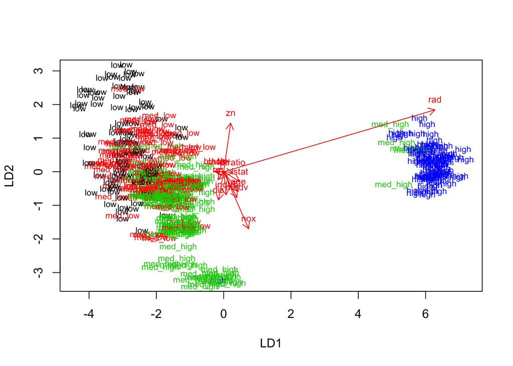

```r
# Function for lda biplot arrows
lda.arrows <- function(x, myscale = 1, arrow_heads = 0.1, color = "red", tex = 0.75, choices = c(1,2)){
  heads <- coef(x)
  arrows(x0 = 0, y0 = 0,
         x1 = myscale * heads[,choices[1]],
         y1 = myscale * heads[,choices[2]], col=color, length = arrow_heads)
  text(myscale * heads[,choices], labels = row.names(heads),
       cex = tex, col=color, pos=3)
}

classes <- as.numeric(train$crime)

# plot the lda results
plot(lda.fit, dimen = 2, col = classes, pch = classes)
lda.arrows(lda.fit, myscale = 2)
```

## LDA results prediction

```r
# predict classes with test data
lda.pred <- predict(lda.fit, newdata = test)

# cross tabulate the results
tab <- table(correct = correct_classes, predicted = lda.pred$class)
tab
```

```
##           predicted
## correct    low med_low med_high high
##   low       16      13        1    0
##   med_low    1      17        3    0
##   med_high   0       9       10    1
##   high       0       0        0   31
```

#### The prediction results as seen above in the diagonal tells us the actual accuracy of LDA. To summarise we can draw the proportions correct accordingly along with other statistics like sensitivity/specificity and a confusion matrix

```r
pred1 <- rbind(tab[1, ]/sum(tab[1, ]), tab[2, ]/sum(tab[2, ]))
pred2 <- rbind(tab[3, ]/sum(tab[3, ]), tab[4, ]/sum(tab[4, ]))

Predict_accuracy <- rbind(pred1, pred2)
rownames(Predict_accuracy) <- colnames(Predict_accuracy)
Predict_accuracy
```

```
##                 low   med_low   med_high high
## low      0.53333333 0.4333333 0.03333333 0.00
## med_low  0.04761905 0.8095238 0.14285714 0.00
## med_high 0.00000000 0.4500000 0.50000000 0.05
## high     0.00000000 0.0000000 0.00000000 1.00
```

```r
require(caret)
confusionMatrix(correct_classes, lda.pred$class)
```

```
## Confusion Matrix and Statistics
##
##           Reference
## Prediction low med_low med_high high
##   low       16      13        1    0
##   med_low    1      17        3    0
##   med_high   0       9       10    1
##   high       0       0        0   31
##
## Overall Statistics
##
##                Accuracy : 0.7255
##                  95% CI : (0.6282, 0.8092)
##     No Information Rate : 0.3824
##     P-Value [Acc > NIR] : 2.161e-12
##
##                   Kappa : 0.634
##  Mcnemar's Test P-Value : NA
##
## Statistics by Class:
##
##                      Class: low Class: med_low Class: med_high Class: high
## Sensitivity              0.9412         0.4359         0.71429      0.9688
## Specificity              0.8353         0.9365         0.88636      1.0000
## Pos Pred Value           0.5333         0.8095         0.50000      1.0000
## Neg Pred Value           0.9861         0.7284         0.95122      0.9859
## Prevalence               0.1667         0.3824         0.13725      0.3137
## Detection Rate           0.1569         0.1667         0.09804      0.3039
## Detection Prevalence     0.2941         0.2059         0.19608      0.3039
## Balanced Accuracy        0.8882         0.6862         0.80032      0.9844
```

## k-means & visualization

```r
# Euclidean distance matrix
boston_scaled <- dplyr::select(boston_scaled, -crime)
dist_eu <- dist(boston_scaled)

# Summary of the distances
summary(dist_eu)
```

```
##    Min. 1st Qu.  Median    Mean 3rd Qu.    Max.
##  0.1343  3.3984  4.7296  4.7597  6.0150 12.5315
```

```r
# Manhattan distance matrix
dist_man <- dist(boston_scaled, method = 'manhattan')

# Summary of the distances
summary(dist_man)
```

```
##    Min. 1st Qu.  Median    Mean 3rd Qu.    Max.
##  0.2645  8.2073 12.0993 12.8752 16.8027 43.5452
```

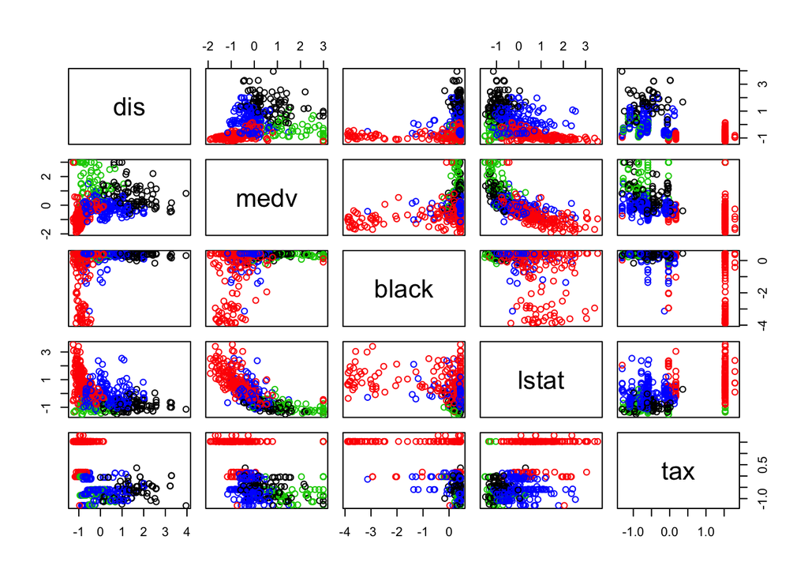

```r
# k-means clustering with 4
km4 <-kmeans(boston_scaled, centers = 4)

# plot the Boston dataset with clusters
# For this, we choose 5 variables - dis, medv, black, lstat and tax
pairs(boston_scaled[c("dis", "medv", "black", "lstat", "tax")], col = km4$cluster)
```

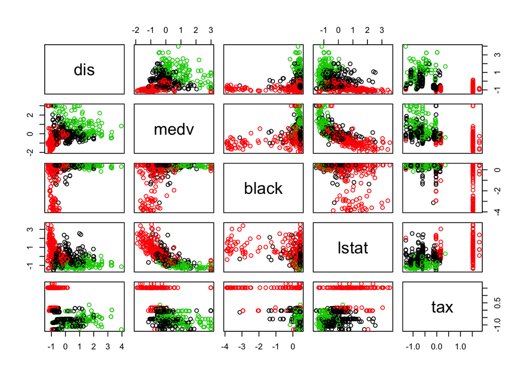

```r
# k-means clustering with 3
km3 <-kmeans(boston_scaled, centers = 3)

# plot the Boston dataset with clusters
# For this, we choose 5 variables - dis, medv, black, lstat and tax
pairs(boston_scaled[c("dis", "medv", "black", "lstat", "tax")], col = km3$cluster)
```

### Finding optimal number of clusters in k-means.

#### To calculate variance explained we could calculate TSS

```r
set.seed(100)

# Compute and plot cluster addition & variance explained for k = 2 to k = 15.
k.max <- 15
data <- boston_scaled
clust_TSS <- sapply(1:k.max,
              function(k){kmeans(data, k, nstart=50,iter.max = 15 )$tot.withinss})
clust_TSS
```

```
##  [1] 6565.000 4207.600 3519.743 3098.744 2746.623 2399.515 2143.440
##  [8] 1955.816 1832.813 1736.480 1637.171 1561.280 1498.560 1464.093
## [15] 1385.043
```

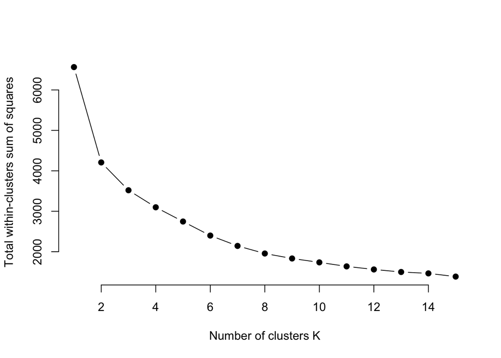

```r
plot(1:k.max, clust_TSS,
     type="b", pch = 19, frame = FALSE,
     xlab="Number of clusters K",
     ylab="Total within-clusters sum of squares")
```

# Bonus

Visualize the results with a biplot (include arrows representing the relationships of the original variables to the LDA solution). Interpret the results. Which variables are the most influencial linear separators for the clusters?

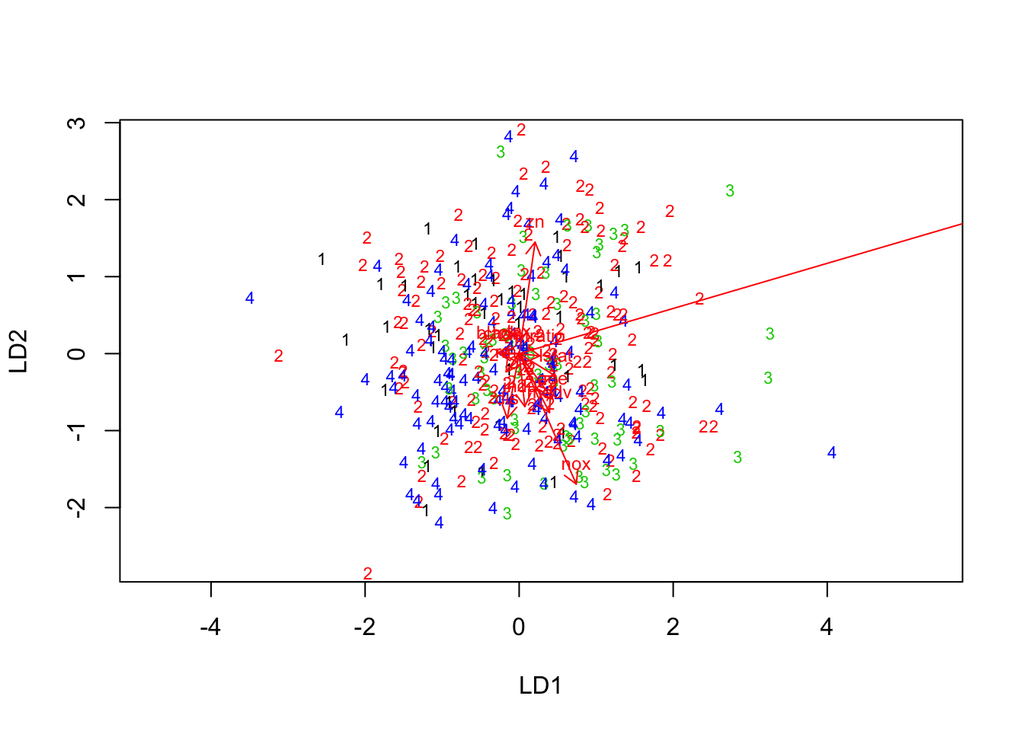

```r
# k-means clustering with 4
km_bonus <-kmeans(boston_scaled, centers = 4)

# Linear discriminant analysis with clusters from k-means as target
mat <- as.matrix(km_bonus$cluster)
cluster_target <- mat[ rownames(mat) %in% rownames(train), ]
lda.fit.bonus <- lda(cluster_target ~., data = train)

# target classes as numeric
classes <- as.numeric(cluster_target)

# Plot the lda results
plot(lda.fit.bonus, dimen = 2, col = classes, pch = classes)
lda.arrows(lda.fit, myscale = 2)
```